# Rein

# Start

Dette er en felles indikator for villrein og tamreinsbestander Utarbeidelsen av metodikken er gjort av Erik Fremstad.

# Import

Datasett med bestandstall, areal, og TRIverdier. Topographic roughenss index brukes til å modellere referansetilstand. For hvert reinområde andgis areal per region.

```r
dat <- read_excel("../data/rein.xlsx")
head(dat)
```

```
## # A tibble: 6 x 13
##   type   navn  navn2 Totalreal fjellareal bestand `TRI-fjell`     E      S     W
##   <chr>  <chr> <chr>     <dbl>      <dbl>   <dbl>       <dbl> <dbl>  <dbl> <dbl>
## 1 Villr~ Sete~ Sete~     7067.     5119.     3500        364.  NA   3212.  1907.
## 2 Villr~ Sete~ Sete~     2433.      660.     2000        437.  NA    660.    NA
## 3 Villr~ Skau~ Skau~      654.      604.       60        573.  NA     NA    604.
## 4 Villr~ Våmu~ Våmu~      449.       51.2     240        382.  NA     51.2   NA
## 5 Villr~ Brat~ Brat~      417.      213.      500        326.  NA    213.    NA
## 6 Villr~ Blef~ Blef~      264.       64.4     140        324.  29.2   35.2   NA
## # ... with 3 more variables: C <dbl>, N <dbl>, totalt <dbl>
```

Kolonnen med total areal (helt til høyre) stemmer nesten med total fjellareal, så jeg kan bruke de vekselsvis.

Rydder

```r
dat <- dplyr::select(dat, -navn2)
```

Så setter jeg alle NA til 0. Dette inkluderer totalbestand for Trollheimen. Trollheimen har tom celle for totalbestand. Siden det er skrevet 0 i cellen for fjellbestand så antar jeg det skal være null i den andre også.

```r
dat[is.na(dat)] <- 0
```

Fordeling av areal mellom regioner.

```r
dat$propN <- dat$N/dat$totalt
dat$propC <- dat$C/dat$totalt
dat$propE <- dat$E/dat$totalt
dat$propW <- dat$W/dat$totalt
dat$propS <- dat$S/dat$totalt
```

# Melt

Nå deler jeg opp villreinområdene i så mange regioner som de inngår i

```r
setDT(dat)
dat2 <- melt(dat,
             measure.vars = c("N", "C", "E", "W", "S"),
             value.name = "area",
             variable.name= "reg",
             na.rm=T)
```

Dette gir fem rader per område. Så tar jeg bort de radene der det ikke finnes noe (fjell)areal

```r
temp <- dat2[dat2$type=="ingen rein",]
dat2 <- dat2[dat2$area>0,]
dat2 <- rbind(dat2, temp)
rm(temp)
```

Så kan jeg regne ut referansetettheter. Her er referanseverdier for tetthet gitt som 75% av bestandsmål. Metoden er beskrevet andre steder, men baseres seg på sammenhengen mellom topgrafisk varisjon og bestandsmålene for villrein.

```r
dat2$ref <- 0.75*1.0759*exp(-0.001*dat2$`TRI-fjell`)
```

Lager noen alternativer

```r
dat2$ref60 <- 0.60*1.0759*exp(-0.001*dat2$`TRI-fjell`)
dat2$ref80 <- 0.80*1.0759*exp(-0.001*dat2$`TRI-fjell`)
```

Det er noen rader med type = ingen rein som vi må kombinere på et vis.

```r
temp <- dat2[dat2$type=="ingen rein",]
dat2 <- dat2[dat2$type!="ingen rein",]
```

```r
temp2 <- temp[temp$navn == "Fjell uten rein - nord" &
                temp$reg %in% c("N"),]

temp3 <- temp[temp$navn == "Fjell uten rein - sør" &
                temp$reg %in% c("E", "S", "W", "C"),]

temp4 <- temp[temp$navn =="Fjellområder uten rein",]
temp4 <- temp4[!duplicated(temp4$reg)]

temp <- rbind(temp2, temp3)
temp$area <- temp4$area[match(temp$reg, temp4$reg)]
```

```r
dat2 <- rbind(dat2, temp)
```

Her er de observerte dyretetthetene. Siden tettheten er antatt lik i fjell og ikke-fjell trenger vi ikke gå veien innom å regne ut bestandstall

```r
dat2$tetthet <- dat2$bestand/dat2$Totalreal
#Endrer NaN til 0
dat2$tetthet[dat2$type=="ingen rein"] <- 0
```

I motsettnign til de fleste andre indikatorer ønsker vi i dtte tilfelle å skalere indikatoren på minst mulig nivå, dvs per delaområde. Dette er fordi det ikke gir mening å hverken summere eller ta gjennomsnitt av tettheter. Man kan ikke la lav tetthet ett sted kompenseer for høye tettheter ett annet sted.

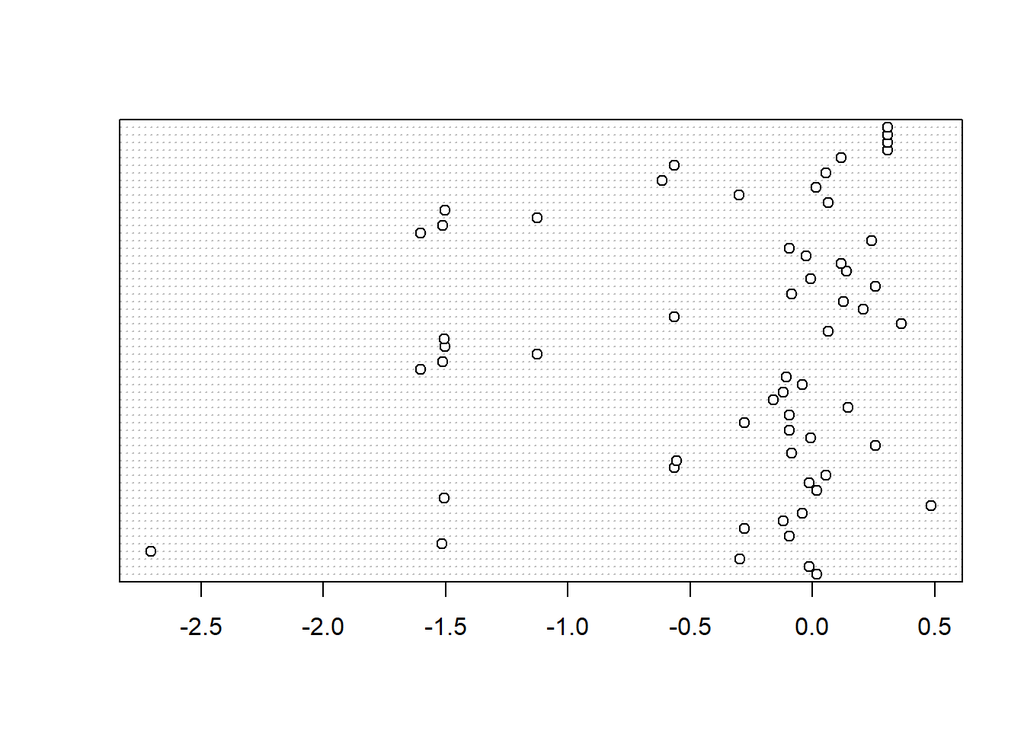

```r
dat2$diff <- dat2$ref-dat2$tetthet
dotchart(dat2$diff)
```

Her må vi ha en tosidig skalering. Erik har laget et forslag til skalering som ser slik ut

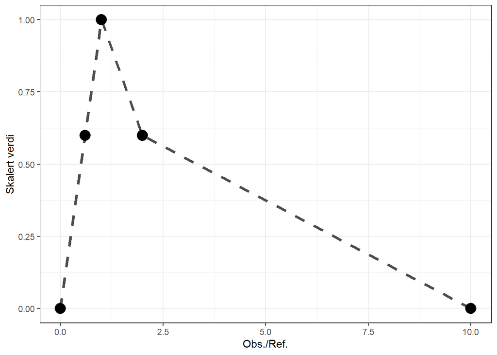

```r
temp <- data.frame(x = c(0, 0.6, 1, 2,10),
                   y = c(0, 0.6, 1, 0.6, 0))

ggplot(data = temp, aes(x = x, y = y))+
  geom_line(size=1.3, linetype="dashed", colour="grey30")+
  geom_point(size=5)+
  theme_bw()+
  ylab("Skalert verdi")+
  xlab("Obs./Ref.")
```

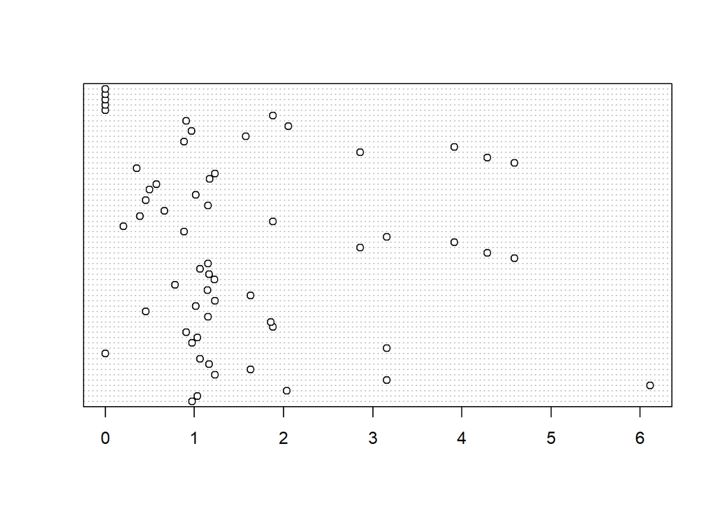

```r
dat2$rat <- dat2$tetthet/dat2$ref
dotchart(dat2$rat)
```

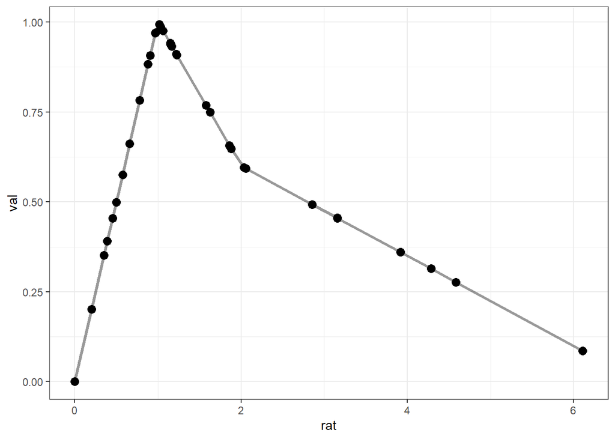

```r
dat2$val <- NA
dat2$val[dat2$rat<1]  <- dat2$rat[dat2$rat<1]
dat2$val[dat2$rat %between% c(1, 2)] <- 1-(0.4*((dat2$rat[dat2$rat %between% c(1, 2)])-1))
dat2$val[dat2$rat >2] <- 0.6-((dat2$rat[dat2$rat >2]-2)/8)
ggplot(data=dat2, aes(x = rat, y = val))+
  geom_line(size=1.2, alpha=.4)+
  geom_point(size=3)+
  theme_bw()
```

Fint.

Så trenger jeg et arealvektet gjennomsnitt per region.

```r
df <- data.table(reg = unique(dat2$reg),
                 val = as.numeric(),
                 X = "rein",
                 year = 2020)
for(i in unique(dat2$reg)){


  temp <- dat2[dat2$reg ==i,]

  df[df$reg==i, "val"] <- weighted.mean(temp$val, temp$area)
}
```

Så må vi ha en verdi for hele Norge Fjellareal per region:

```r
wgt <- readRDS("../data/fjellareal.rds")
wgt$Fjellareal2 <- wgt$Fjellareal/max(wgt$Fjellareal)
wgt$reg <- c("N", "C", "E", "W", "S")
temp <- df
temp$wgt <- wgt$Fjellareal2[match(temp$reg, wgt$reg)]
```

```r
nor <- data.frame(reg = "Norge",
                  val = weighted.mean(temp$val, temp$wgt),
                  X = "rein",
                  year = 2020)
df <- rbind(df, nor)
df
```

```
##      reg       val    X year
## 1:     N 0.5228825 rein 2020
## 2:     C 0.6156114 rein 2020
## 3:     E 0.6611237 rein 2020
## 4:     W 0.4452500 rein 2020
## 5:     S 0.7118004 rein 2020
## 6: Norge 0.5556757 rein 2020
```

Det er kanskje mulig å kvantifisere usikkerhet ved å innføre usikkerhet i referanseverdien, men det bryter også med noen prinsipper i ØT, så jeg venter i hvertfall med å gjøre det.

# Plotting

```r
temp2 <- c("N", "C", "E", "S", "W", "Norge")
temp3 <- c("Nord-Norge", "Midt-Norge", "Østlandet", "Sørlandet", "Vestlandet", "Norge")
```

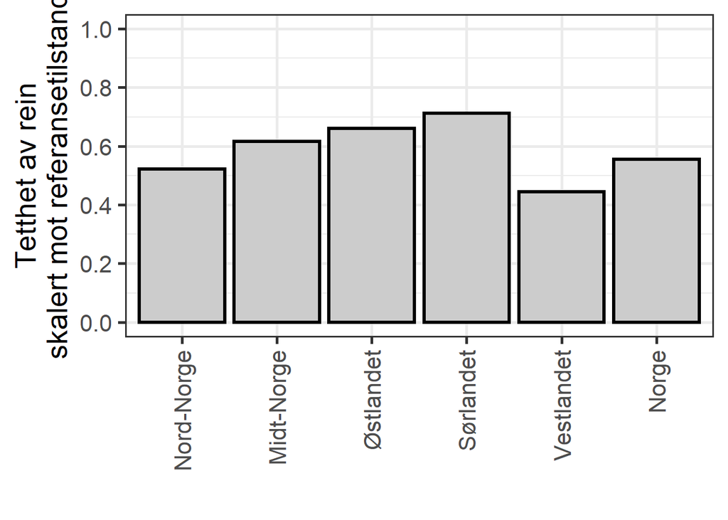

```r
(gg <- ggplot(data = df, aes(x = factor(reg, levels = temp2), y = val))+
  geom_bar(stat="identity", colour="black", size=1.2,
           fill="grey80")+
  theme_bw(base_size = 20)+
  ylab("Tetthet av rein\nskalert mot referansetilstand")+
  xlab("")+
  theme(
    axis.text.x = element_text(angle = 90, vjust = 0.5, hjust=1)
  )+
   scale_x_discrete(breaks = temp2,
                    labels = temp3)+
   scale_y_continuous(breaks = seq(0,1,.2),
                      limits = c(0,1))
)
```

```r
png("../output/indicatorPlots/skalert/rein.png",
    units="in", width=6, height=8, res=300)
gg
dev.off()
```

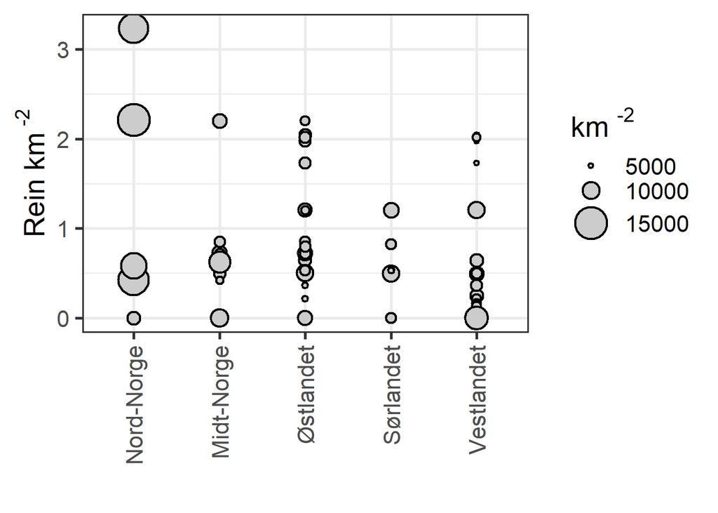

```r
(gg2 <- ggplot(data = dat2, aes(x = factor(reg, levels = temp2), y = tetthet))+
  geom_point(aes(size = area),
             shape=21,
             colour="black",
             stroke=1.2,
             fill="grey80")+
  scale_size_continuous(range = c(1, 10))+
  theme_bw(base_size = 20)+
  ylab(expression(paste("Rein km "^"-2")))+
  xlab("")+
  theme(
    axis.text.x = element_text(angle = 90, vjust = 0.5, hjust=1)
  )+
   scale_x_discrete(breaks = temp2,
                    labels = temp3)+
  guides(
    size=guide_legend(override.aes = list(size = c(1, 5, 10)),
                      title = expression(paste("km "^"-2")))
  )
)
```

```r
png("../output/indicatorPlots/uskalert/rein_tettheter.png",
    units="in", width=6, height=8, res=300)
gg2
dev.off()
```

```r
write.csv(df, "../output/indicator_values/rein.csv", row.names = F)
```